# Notebook

### Sarah, Wassim, Yakine, Jean-Louis

## Importation des packages

```r
library(ade4)
library(factoextra)
library(ggplot2)
library(GGally)
library(lattice)
library(corrplot)
library(car)
```

```r
# Extraction de la base de données
data_baseball <- read.csv("Baseball.csv", header = TRUE, sep=";")
head(data_baseball)
print(paste("nombre de lignes =", nrow(data_baseball)))
print(paste("nombre de colones =", ncol(data_baseball)))
str(data_baseball)
```

A data.frame: 6 × 24

|  | Name <chr> | Bat_times_86 <int> | Hits_86 <int> | Home_runs_1986 <int> | Runs_1986 <int> | Runs_batted_1986 <int> | Walks_1986 <int> | Longevity <int> | Bat_times_career <int> | Hits_career <int> | ⋯ | League_1986 <chr> | Division_1986 <chr> | Team_1986 <chr> | Position_1986 <chr> | Put_outs_1986 <int> | Assists_1986 <int> | Errors_1986 <int> | Salary_1987 <dbl> | League_1987 <chr> | Team_1987 <chr> |
| --- | --- | --- | --- | --- | --- | --- | --- | --- | --- | --- | --- | --- | --- | --- | --- | --- | --- | --- | --- | --- | --- |
| 1 | Andy Allanson | 293 | 66 | 1 | 30 | 29 | 14 | 1 | 293 | 66 | ⋯ | A | E | Cle. | C | 446 | 33 | 20 | NA | A | Cle. |
| 2 | Alan Ashby | 315 | 81 | 7 | 24 | 38 | 39 | 14 | 3449 | 835 | ⋯ | N | W | Hou. | C | 632 | 43 | 10 | 475.0 | N | Hou. |
| 3 | Alvin Davis | 479 | 130 | 18 | 66 | 72 | 76 | 3 | 1624 | 457 | ⋯ | A | W | Sea. | 1B | 880 | 82 | 14 | 480.0 | A | Sea. |
| 4 | Andre Dawson | 496 | 141 | 20 | 65 | 78 | 37 | 11 | 5628 | 1575 | ⋯ | N | E | Mon. | RF | 200 | 11 | 3 | 500.0 | N | Chi. |
| 5 | Andres Galarraga | 321 | 87 | 10 | 39 | 42 | 30 | 2 | 396 | 101 | ⋯ | N | E | Mon. | 1B | 805 | 40 | 4 | 91.5 | N | Mon. |
| 6 | Alfredo Griffin | 594 | 169 | 4 | 74 | 51 | 35 | 11 | 4408 | 1133 | ⋯ | A | W | Oak. | SS | 282 | 421 | 25 | 750.0 | A | Oak. |

```
[1] "nombre de lignes = 322"
[1] "nombre de colones = 24"
'data.frame':	322 obs. of  24 variables:
 $ Name              : chr  "Andy Allanson" "Alan Ashby" "Alvin Davis" "Andre Dawson" ...
 $ Bat_times_86      : int  293 315 479 496 321 594 185 298 323 401 ...
 $ Hits_86           : int  66 81 130 141 87 169 37 73 81 92 ...
 $ Home_runs_1986    : int  1 7 18 20 10 4 1 0 6 17 ...
 $ Runs_1986         : int  30 24 66 65 39 74 23 24 26 49 ...
 $ Runs_batted_1986  : int  29 38 72 78 42 51 8 24 32 66 ...
 $ Walks_1986        : int  14 39 76 37 30 35 21 7 8 65 ...
 $ Longevity         : int  1 14 3 11 2 11 2 3 2 13 ...
 $ Bat_times_career  : int  293 3449 1624 5628 396 4408 214 509 341 5206 ...
 $ Hits_career       : int  66 835 457 1575 101 1133 42 108 86 1332 ...
 $ Home_runs_career  : int  1 69 63 225 12 19 1 0 6 253 ...
 $ Runs_career       : int  30 321 224 828 48 501 30 41 32 784 ...
 $ Runs_batted_career: int  29 414 266 838 46 336 9 37 34 890 ...
 $ Walks_career      : int  14 375 263 354 33 194 24 12 8 866 ...
 $ League_1986       : chr  "A" "N" "A" "N" ...
 $ Division_1986     : chr  "E" "W" "W" "E" ...
 $ Team_1986         : chr  "Cle." "Hou." "Sea." "Mon." ...
 $ Position_1986     : chr  "C" "C" "1B" "RF" ...
 $ Put_outs_1986     : int  446 632 880 200 805 282 76 121 143 0 ...
 $ Assists_1986      : int  33 43 82 11 40 421 127 283 290 0 ...
 $ Errors_1986       : int  20 10 14 3 4 25 7 9 19 0 ...
 $ Salary_1987       : num  NA 475 480 500 91.5 750 70 100 75 1100 ...
 $ League_1987       : chr  "A" "N" "A" "N" ...
 $ Team_1987         : chr  "Cle." "Hou." "Sea." "Chi." ...
```

```r
summary(data_baseball)
```

```
     Name            Bat_times_86      Hits_86      Home_runs_1986
 Length:322         Min.   :127.0   Min.   : 31.0   Min.   :  0.00
 Class :character   1st Qu.:272.0   1st Qu.: 68.0   1st Qu.:  4.00
 Mode  :character   Median :390.5   Median : 98.5   Median :  8.50
                    Mean   :390.1   Mean   :103.4   Mean   : 11.51
                    3rd Qu.:512.8   3rd Qu.:137.8   3rd Qu.: 16.75
                    Max.   :687.0   Max.   :238.0   Max.   :141.00

   Runs_1986      Runs_batted_1986   Walks_1986       Longevity
 Min.   : 12.00   Min.   :  8.00   Min.   :  3.00   Min.   : 1.000
 1st Qu.: 32.00   1st Qu.: 29.00   1st Qu.: 22.00   1st Qu.: 4.000
 Median : 48.00   Median : 45.00   Median : 35.50   Median : 6.000
 Mean   : 52.22   Mean   : 49.37   Mean   : 39.86   Mean   : 7.671
 3rd Qu.: 70.00   3rd Qu.: 65.00   3rd Qu.: 54.00   3rd Qu.:11.000
 Max.   :130.00   Max.   :121.00   Max.   :105.00   Max.   :24.000

 Bat_times_career   Hits_career     Home_runs_career  Runs_career
 Min.   :  166.0   Min.   :  34.0   Min.   :  0.00   Min.   :  18.0
 1st Qu.:  911.2   1st Qu.: 227.2   1st Qu.: 16.00   1st Qu.: 106.2
 Median : 2065.0   Median : 552.0   Median : 40.00   Median : 266.0
 Mean   : 2763.1   Mean   : 747.7   Mean   : 74.09   Mean   : 374.3
 3rd Qu.: 4068.5   3rd Qu.:1095.8   3rd Qu.: 95.50   3rd Qu.: 556.5
 Max.   :14053.0   Max.   :4256.0   Max.   :548.00   Max.   :2165.0

 Runs_batted_career  Walks_career    League_1986        Division_1986
 Min.   :   9.00    Min.   :   8.0   Length:322         Length:322
 1st Qu.:  98.25    1st Qu.:  76.0   Class :character   Class :character
 Median : 250.00    Median : 178.5   Mode  :character   Mode  :character
 Mean   : 347.61    Mean   : 273.4
 3rd Qu.: 461.00    3rd Qu.: 370.8
 Max.   :1659.00    Max.   :1566.0

  Team_1986         Position_1986      Put_outs_1986     Assists_1986
 Length:322         Length:322         Min.   :   0.0   Min.   :  0.0
 Class :character   Class :character   1st Qu.: 109.2   1st Qu.:  7.0
 Mode  :character   Mode  :character   Median : 212.0   Median : 39.5
                                       Mean   : 288.9   Mean   :106.9
                                       3rd Qu.: 325.0   3rd Qu.:166.0
                                       Max.   :1378.0   Max.   :492.0

  Errors_1986     Salary_1987     League_1987         Team_1987
 Min.   : 0.00   Min.   :  67.5   Length:322         Length:322
 1st Qu.: 3.00   1st Qu.: 193.0   Class :character   Class :character
 Median : 6.00   Median : 430.0   Mode  :character   Mode  :character
 Mean   : 8.04   Mean   : 542.2
 3rd Qu.:11.00   3rd Qu.: 750.0
 Max.   :32.00   Max.   :2460.0
                 NA's   :59
```

```r
# Calcul des valeurs manquantes
missing_summary <- data.frame(
  Column = names(data_baseball),
  Missing_Count = colSums(is.na(data_baseball)),
  Missing_Percentage = colMeans(is.na(data_baseball)) * 100
)

print(missing_summary, row.names = FALSE)
# Calcul du nombre de valeurs manquantes par colonne
table(colSums(is.na(data_baseball)))
```

```
             Column Missing_Count Missing_Percentage
               Name             0            0.00000
       Bat_times_86             0            0.00000
            Hits_86             0            0.00000
     Home_runs_1986             0            0.00000
          Runs_1986             0            0.00000
   Runs_batted_1986             0            0.00000
         Walks_1986             0            0.00000
          Longevity             0            0.00000
   Bat_times_career             0            0.00000
        Hits_career             0            0.00000
   Home_runs_career             0            0.00000
        Runs_career             0            0.00000
 Runs_batted_career             0            0.00000
       Walks_career             0            0.00000
        League_1986             0            0.00000
      Division_1986             0            0.00000
          Team_1986             0            0.00000
      Position_1986             0            0.00000
      Put_outs_1986             0            0.00000
       Assists_1986             0            0.00000
        Errors_1986             0            0.00000
        Salary_1987            59           18.32298
        League_1987             0            0.00000
          Team_1987             0            0.00000
```

```
 0 59
23  1
```

```r
# Base de données sans les valeurs manquantes
Baseball <- na.omit(data_baseball)

head(Baseball)
summary(Baseball)
missing_summary <- data.frame(
  Column = names(Baseball),
  Missing_Count = colSums(is.na(Baseball)),
  Missing_Percentage = colMeans(is.na(Baseball)) * 100
)
print(missing_summary, row.names = FALSE)
```

A data.frame: 6 × 24

|  | Name <chr> | Bat_times_86 <int> | Hits_86 <int> | Home_runs_1986 <int> | Runs_1986 <int> | Runs_batted_1986 <int> | Walks_1986 <int> | Longevity <int> | Bat_times_career <int> | Hits_career <int> | ⋯ | League_1986 <chr> | Division_1986 <chr> | Team_1986 <chr> | Position_1986 <chr> | Put_outs_1986 <int> | Assists_1986 <int> | Errors_1986 <int> | Salary_1987 <dbl> | League_1987 <chr> | Team_1987 <chr> |
| --- | --- | --- | --- | --- | --- | --- | --- | --- | --- | --- | --- | --- | --- | --- | --- | --- | --- | --- | --- | --- | --- |
| 2 | Alan Ashby | 315 | 81 | 7 | 24 | 38 | 39 | 14 | 3449 | 835 | ⋯ | N | W | Hou. | C | 632 | 43 | 10 | 475.0 | N | Hou. |
| 3 | Alvin Davis | 479 | 130 | 18 | 66 | 72 | 76 | 3 | 1624 | 457 | ⋯ | A | W | Sea. | 1B | 880 | 82 | 14 | 480.0 | A | Sea. |
| 4 | Andre Dawson | 496 | 141 | 20 | 65 | 78 | 37 | 11 | 5628 | 1575 | ⋯ | N | E | Mon. | RF | 200 | 11 | 3 | 500.0 | N | Chi. |
| 5 | Andres Galarraga | 321 | 87 | 10 | 39 | 42 | 30 | 2 | 396 | 101 | ⋯ | N | E | Mon. | 1B | 805 | 40 | 4 | 91.5 | N | Mon. |
| 6 | Alfredo Griffin | 594 | 169 | 4 | 74 | 51 | 35 | 11 | 4408 | 1133 | ⋯ | A | W | Oak. | SS | 282 | 421 | 25 | 750.0 | A | Oak. |
| 7 | Al Newman | 185 | 37 | 1 | 23 | 8 | 21 | 2 | 214 | 42 | ⋯ | N | E | Mon. | 2B | 76 | 127 | 7 | 70.0 | A | Min. |

```
     Name            Bat_times_86      Hits_86      Home_runs_1986
 Length:263         Min.   :127.0   Min.   : 32.0   Min.   : 0.00
 Class :character   1st Qu.:285.5   1st Qu.: 73.0   1st Qu.: 5.00
 Mode  :character   Median :416.0   Median :108.0   Median : 9.00
                    Mean   :408.3   Mean   :109.2   Mean   :11.83
                    3rd Qu.:527.0   3rd Qu.:142.0   3rd Qu.:18.00
                    Max.   :687.0   Max.   :238.0   Max.   :40.00
   Runs_1986      Runs_batted_1986   Walks_1986       Longevity
 Min.   : 13.00   Min.   :  8.00   Min.   :  3.00   Min.   : 1.00
 1st Qu.: 34.00   1st Qu.: 31.00   1st Qu.: 24.00   1st Qu.: 4.00
 Median : 53.00   Median : 47.00   Median : 37.00   Median : 6.00
 Mean   : 55.49   Mean   : 52.29   Mean   : 41.72   Mean   : 7.38
 3rd Qu.: 73.00   3rd Qu.: 71.50   3rd Qu.: 57.50   3rd Qu.:10.50
 Max.   :130.00   Max.   :121.00   Max.   :105.00   Max.   :24.00
 Bat_times_career   Hits_career     Home_runs_career  Runs_career
 Min.   :  181.0   Min.   :  42.0   Min.   :  0.00   Min.   :  18.0
 1st Qu.:  911.5   1st Qu.: 219.5   1st Qu.: 16.00   1st Qu.: 110.5
 Median : 1966.0   Median : 541.0   Median : 40.00   Median : 265.0
 Mean   : 2700.9   Mean   : 733.9   Mean   : 71.48   Mean   : 368.1
 3rd Qu.: 3914.5   3rd Qu.:1064.0   3rd Qu.: 93.00   3rd Qu.: 503.0
 Max.   :14053.0   Max.   :4256.0   Max.   :548.00   Max.   :2165.0
 Runs_batted_career  Walks_career    League_1986        Division_1986
 Min.   :   9.0     Min.   :   8.0   Length:263         Length:263
 1st Qu.:  99.5     1st Qu.:  77.0   Class :character   Class :character
 Median : 249.0     Median : 175.0   Mode  :character   Mode  :character
 Mean   : 337.9     Mean   : 266.5
 3rd Qu.: 432.5     3rd Qu.: 333.0
 Max.   :1659.0     Max.   :1566.0
  Team_1986         Position_1986      Put_outs_1986     Assists_1986
 Length:263         Length:263         Min.   :   0.0   Min.   :  0.0
 Class :character   Class :character   1st Qu.: 113.5   1st Qu.:  8.0
 Mode  :character   Mode  :character   Median : 224.0   Median : 45.0
                                       Mean   : 290.7   Mean   :118.8
                                       3rd Qu.: 322.5   3rd Qu.:192.0
                                       Max.   :1377.0   Max.   :492.0
  Errors_1986      Salary_1987     League_1987         Team_1987
 Min.   : 0.000   Min.   :  67.5   Length:263         Length:263
 1st Qu.: 3.000   1st Qu.: 193.0   Class :character   Class :character
 Median : 7.000   Median : 430.0   Mode  :character   Mode  :character
 Mean   : 8.593   Mean   : 542.2
 3rd Qu.:13.000   3rd Qu.: 750.0
 Max.   :32.000   Max.   :2460.0
```

```
             Column Missing_Count Missing_Percentage
               Name             0                  0
       Bat_times_86             0                  0
            Hits_86             0                  0
     Home_runs_1986             0                  0
          Runs_1986             0                  0
   Runs_batted_1986             0                  0
         Walks_1986             0                  0
          Longevity             0                  0
   Bat_times_career             0                  0
        Hits_career             0                  0
   Home_runs_career             0                  0
        Runs_career             0                  0
 Runs_batted_career             0                  0
       Walks_career             0                  0
        League_1986             0                  0
      Division_1986             0                  0
          Team_1986             0                  0
      Position_1986             0                  0
      Put_outs_1986             0                  0
       Assists_1986             0                  0
        Errors_1986             0                  0
        Salary_1987             0                  0
        League_1987             0                  0
          Team_1987             0                  0
```

# 1. Analyse descriptive des données

## 1.1. Présentation générale de la base de donnée

# Explication des variables

1. **Name** : Le nom du joueur.
2. **Bat_times_86** : Le nombre de fois où le joueur est allé au bâton (battre) en 1986. Cela indique combien de fois un joueur a eu une chance de frapper la balle pendant la saison.
3. **Hits_86** : Le nombre de coups sûrs réalisés par le joueur en 1986. Un "hit" est un coup où le joueur atteint la base avec succès.
4. **Home_runs_1986** : Le nombre de **home runs** (coups de circuit) réalisés par le joueur en 1986. Un home run se produit lorsque le joueur frappe la balle et la fait sortir du terrain sans qu'elle soit attrapée, lui permettant ainsi de faire un tour complet des bases.
5. **Runs_1986** : Le nombre de points (runs) marqués par le joueur en 1986. Un "run" est marqué lorsqu'un joueur réussit à faire le tour complet des bases et revient au marbre.
6. **Runs_batted_1986** : Le nombre de **runs batted in** (RBI) réalisés par le joueur en 1986. Cela représente le nombre de points marqués par des coéquipiers grâce à des actions du joueur (comme des coups sûrs ou des coups de circuit).
7. **Walks_1986** : Le nombre de fois où le joueur a obtenu un **walk** en 1986. Un "walk" (ou base sur balles) se produit lorsqu'un lanceur lance quatre balles non frappées, ce qui permet au joueur de se rendre automatiquement à la première base.
8. **Longevity** : Le nombre d'années que le joueur a passées dans le **major league** (grandes ligues). Cela montre la durée de sa carrière professionnelle en baseball.
9. **Bat_times_career** : Le nombre total de fois où le joueur est allé au bâton tout au long de sa carrière.
10. **Hits_career** : Le nombre total de coups sûrs réalisés par le joueur tout au long de sa carrière.
11. **Home_runs_career** : Le nombre total de **home runs** (coups de circuit) réalisés par le joueur durant sa carrière.
12. **Runs_career** : Le nombre total de **runs** (points) marqués par le joueur pendant sa carrière.
13. **Runs_batted_career** : Le nombre total de **runs batted in** (RBI) réalisés par le joueur au cours de sa carrière.
14. **Walks_career** : Le nombre total de **walks** obtenus par le joueur pendant sa carrière.
15. **League_1986** : La ligue dans laquelle le joueur a joué en 1986. Par exemple, "A" pour American League et "N" pour National League.
16. **Division_1986** : La division de la ligue où le joueur a joué en 1986. Par exemple, "E" pour la division Est.
17. **Team_1986** : L'équipe dans laquelle le joueur a joué en 1986. Cela pourrait être un abréviation de l'équipe, comme "Hou." pour Houston Astros, "Cle." pour Cleveland Indians, etc.
18. **Position_1986** : La position occupée par le joueur en 1986. Par exemple, "C" pour un **catcher**, "1B" pour un **premier base**, "2B" pour un **deuxième base**, etc.
19. **Put_outs_1986** : Le nombre de **put outs** réalisés par le joueur en 1986. Un "put out" se produit lorsqu'un joueur est responsable de la mise hors de course d'un autre joueur (par exemple, en attrapant une balle ou en lançant la balle à la base).
20. **Assists_1986** : Le nombre d'**assists** réalisés par le joueur en 1986. Une "assist" est créditée lorsqu'un joueur aide à éliminer un autre joueur, généralement en lançant la balle à un coéquipier pour un put out.
21. **Errors_1986** : Le nombre d'**erreurs** commises par le joueur en 1986. Une erreur se produit lorsqu'un joueur fait une erreur qui permet à un adversaire de se rendre en base ou de marquer un point.
22. **Salary_1987** : Le salaire du joueur pour l'année 1987. C'est le montant qu'un joueur a gagné pour la saison.
23. **League_1987** : La ligue dans laquelle le joueur a joué en 1987, similaire à la variable pour 1986.
24. **Team_1987** : L'équipe pour laquelle le joueur a joué en 1987.

## 1.2. Statistique générale de la base de donnée

```r
numeric_vars <- sapply(Baseball, is.numeric) # variables numériques

# Calculer les statistiques descriptives
descriptive_stats <- data.frame(
  Variable = names(Baseball)[numeric_vars],
  Mean = sapply(Baseball[, numeric_vars], mean, na.rm = TRUE),
  Median = sapply(Baseball[, numeric_vars], median, na.rm = TRUE),
  SD = sapply(Baseball[, numeric_vars], sd, na.rm = TRUE),
  Min = sapply(Baseball[, numeric_vars], min, na.rm = TRUE),
  Max = sapply(Baseball[, numeric_vars], max, na.rm = TRUE)
)

print(descriptive_stats, row.names = FALSE)
```

```
           Variable        Mean Median          SD   Min   Max
       Bat_times_86  408.285171    416  142.633058 127.0   687
            Hits_86  109.159696    108   43.993289  32.0   238
     Home_runs_1986   11.825095      9    8.826131   0.0    40
          Runs_1986   55.490494     53   25.073763  13.0   130
   Runs_batted_1986   52.288973     47   25.713189   8.0   121
         Walks_1986   41.722433     37   21.507032   3.0   105
          Longevity    7.380228      6    4.790248   1.0    24
   Bat_times_career 2700.893536   1966 2290.315240 181.0 14053
        Hits_career  733.916350    541  648.900121  42.0  4256
   Home_runs_career   71.475285     40   86.041078   0.0   548
        Runs_career  368.076046    265  334.845723  18.0  2165
 Runs_batted_career  337.904943    249  328.419885   9.0  1659
       Walks_career  266.547529    175  271.367565   8.0  1566
      Put_outs_1986  290.711027    224  279.934575   0.0  1377
       Assists_1986  118.760456     45  145.080577   0.0   492
        Errors_1986    8.593156      7    6.606574   0.0    32
        Salary_1987  542.199646    430  449.977547  67.5  2460
```

### 1.3.1. Variable Salary

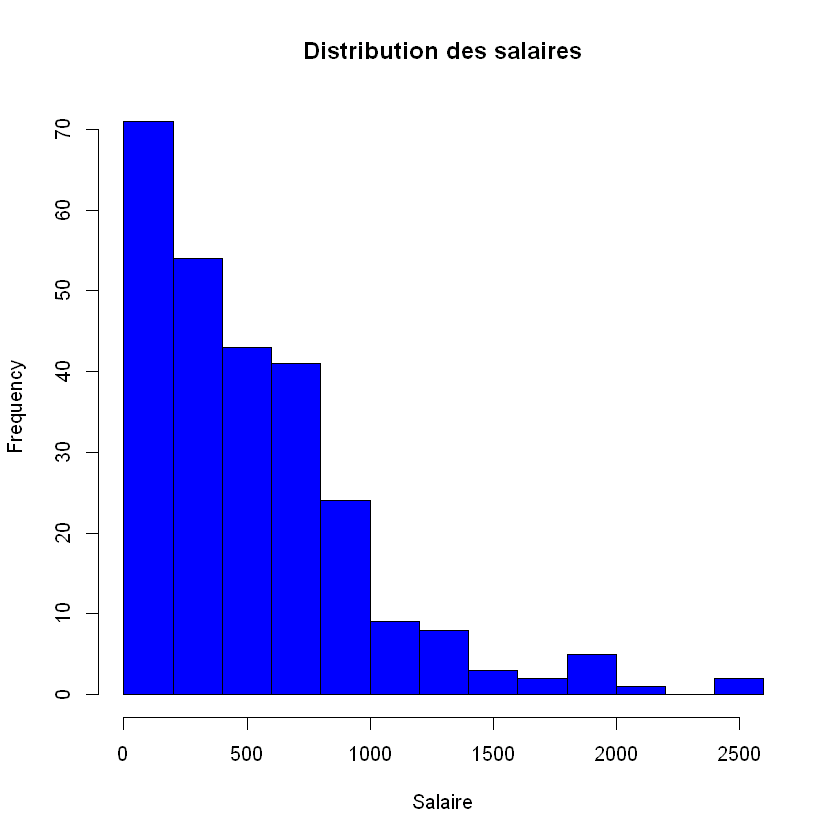

```r
hist(Baseball$Salary_1987, main = "Distribution des salaires", xlab = "Salaire", col = "blue")
```

```
   Min. 1st Qu.  Median    Mean 3rd Qu.    Max.
   67.5   193.0   430.0   542.2   750.0  2460.0
```

```
[1] "Intervalle interquartile :  557"
```

A data.frame: 11 × 24

|  | Name <chr> | Bat_times_86 <int> | Hits_86 <int> | Home_runs_1986 <int> | Runs_1986 <int> | Runs_batted_1986 <int> | Walks_1986 <int> | Longevity <int> | Bat_times_career <int> | Hits_career <int> | ⋯ | League_1986 <chr> | Division_1986 <chr> | Team_1986 <chr> | Position_1986 <chr> | Put_outs_1986 <int> | Assists_1986 <int> | Errors_1986 <int> | Salary_1987 <dbl> | League_1987 <chr> | Team_1987 <chr> |
| --- | --- | --- | --- | --- | --- | --- | --- | --- | --- | --- | --- | --- | --- | --- | --- | --- | --- | --- | --- | --- | --- |
| 83 | Don Mattingly | 677 | 238 | 31 | 117 | 113 | 53 | 5 | 2223 | 737 | ⋯ | A | E | N.Y. | 1B | 1377 | 100 | 6 | 1975.000 | A | N.Y. |
| 85 | Dale Murphy | 614 | 163 | 29 | 89 | 83 | 75 | 11 | 5017 | 1388 | ⋯ | N | W | Atl. | CF | 303 | 6 | 6 | 1900.000 | N | Atl. |
| 97 | Dave Winfield | 565 | 148 | 24 | 90 | 104 | 77 | 14 | 7287 | 2083 | ⋯ | A | E | N.Y. | RF | 292 | 9 | 5 | 1861.460 | A | N.Y. |
| 101 | Eddie Murray | 495 | 151 | 17 | 61 | 84 | 78 | 10 | 5624 | 1679 | ⋯ | A | E | Bal. | 1B | 1045 | 88 | 13 | 2460.000 | A | Bal. |
| 113 | Gary Carter | 490 | 125 | 24 | 81 | 105 | 62 | 13 | 6063 | 1646 | ⋯ | N | E | N.Y. | C | 869 | 62 | 8 | 1925.571 | N | N.Y. |
| 164 | Jim Rice | 618 | 200 | 20 | 98 | 110 | 62 | 13 | 7127 | 2163 | ⋯ | A | E | Bos. | LF | 330 | 16 | 8 | 2412.500 | A | Bos. |
| 180 | Keith Hernandez | 551 | 171 | 13 | 94 | 83 | 94 | 13 | 6090 | 1840 | ⋯ | N | E | N.Y. | 1B | 1199 | 149 | 5 | 1800.000 | N | N.Y. |
| 218 | Mike Schmidt | 552 | 160 | 37 | 97 | 119 | 89 | 15 | 7292 | 1954 | ⋯ | N | E | Phi. | 3B | 78 | 220 | 6 | 2127.333 | N | Phi. |
| 230 | Ozzie Smith | 514 | 144 | 0 | 67 | 54 | 79 | 9 | 4739 | 1169 | ⋯ | N | E | St.L. | SS | 229 | 453 | 15 | 1940.000 | N | St.L. |
| 249 | Rickey Henderson | 608 | 160 | 28 | 130 | 74 | 89 | 8 | 4071 | 1182 | ⋯ | A | E | N.Y. | CF | 426 | 4 | 6 | 1670.000 | A | N.Y. |
| 314 | Wade Boggs | 580 | 207 | 8 | 107 | 71 | 105 | 5 | 2778 | 978 | ⋯ | A | E | Bos. | 3B | 121 | 267 | 19 | 1600.000 | A | Bos. |

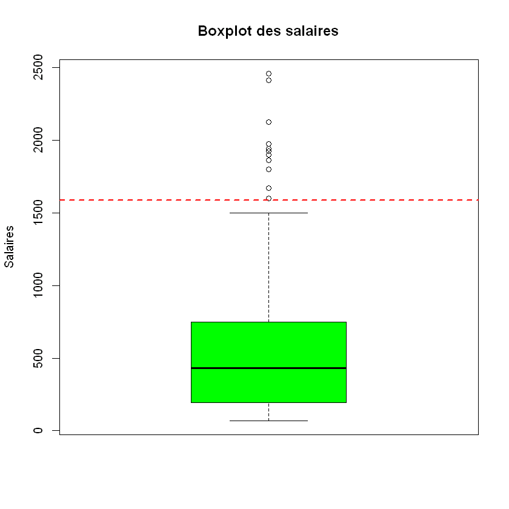

```r
summary(Baseball$Salary_1987)

Q1 <- quantile(Baseball$Salary_1987, 0.25, na.rm = TRUE)  # 1er quartile
Q3 <- quantile(Baseball$Salary_1987, 0.75, na.rm = TRUE)  # 3e quartile
IQR <- Q3 - Q1
print(paste("Intervalle interquartile : ",IQR))

# Calcul des limites
lower_limit <- Q1 - 1.5 * IQR
upper_limit <- Q3 + 1.5 * IQR

outliers <- Baseball[Baseball$Salary_1987 > upper_limit, ] # on séléctionne toutes les gens qui ont des données supérieurs à Q3
                                                                # ont peut voir ça sur le boxplot
View(outliers)
boxplot(Baseball$Salary_1987, main = "Boxplot des salaires", ylab = "Salaires", col = "green")
abline(h = upper_limit, col = "red", lwd = 2, lty = 2)
```

```r
# Calcul de la moyenne et de la médiane des salaires par ligue
moy_salary_league_86 <- tapply(Baseball$Salary_1987, Baseball$League_1986, mean, na.rm = TRUE)
med_salary_league_86 <- tapply(Baseball$Salary_1987, Baseball$League_1986, median, na.rm = TRUE)

moy_med_86 <- data.frame(
  Ligue = names(moy_salary_league_86),
  Moyenne_Salaire = round(moy_salary_league_86, 2),
  Mediane_Salaire = round(med_salary_league_86, 2)
)

# Affichage du tableau avec kable pour une sortie lisible
library(knitr)

kable(moy_med_86, caption = "Moyenne et Médiane des Salaires par Ligue (1886)",
      col.names = c("Ligue", "Moyenne", "Médiane"), format = "markdown")


moy_salary_league_87 <- tapply(Baseball$Salary_1987, Baseball$League_1987, mean, na.rm = TRUE)
med_salary_league_87 <- tapply(Baseball$Salary_1987, Baseball$League_1987, median, na.rm = TRUE)

moy_med_87 <- data.frame(
  Ligue = names(moy_salary_league_87),
  Moyenne_Salaire = round(moy_salary_league_87, 2),
  Mediane_Salaire = round(med_salary_league_87, 2)
)
kable(moy_med_87, caption = "Moyenne et Médiane des Salaires par Ligue (1987)",
      col.names = c("Ligue", "Moyenne", "Médiane"), format = "markdown")
```

```
Table: Moyenne et Médiane des Salaires par Ligue (1886)

|   |Ligue | Moyenne| Médiane|
|:--|:-----|-------:|-------:|
|A  |A     |  543.44|   420.0|
|N  |N     |  540.81|   462.5|
```

```
Table: Moyenne et Médiane des Salaires par Ligue (1987)

|   |Ligue | Moyenne| Médiane|
|:--|:-----|-------:|-------:|
|A  |A     |  538.53|     400|
|N  |N     |  546.44|     495|
```

### 1.3.2. Test des moyennes des salaires pour chaque groupe de League_1986 et League_1987

```r
# Test sur les moyennes de chaque League
salaire_league_1986_N <- Baseball$Salary_1987[Baseball$League_1986 == "N"]
salaire_league_1986_A <- Baseball$Salary_1987[Baseball$League_1986 == "A"]
salaire_league_1987_N <- Baseball$Salary_1987[Baseball$League_1987 == "N"]
salaire_league_1987_A <- Baseball$Salary_1987[Baseball$League_1987 == "A"]

var.test(salaire_league_1986_N,salaire_league_1986_A)
t.test(Salary_1987 ~ League_1986,data=Baseball,var.equal = FALSE)
t.test(Salary_1987 ~ League_1987,data=Baseball,var.equal = FALSE)
```

```
	F test to compare two variances

data:  salaire_league_1986_N and salaire_league_1986_A
F = 0.87773, num df = 123, denom df = 138, p-value = 0.4607
alternative hypothesis: true ratio of variances is not equal to 1
95 percent confidence interval:
 0.6225652 1.2417739
sample estimates:
ratio of variances
         0.8777296
```

```
	Welch Two Sample t-test

data:  Salary_1987 by League_1986
t = 0.047354, df = 260.36, p-value = 0.9623
alternative hypothesis: true difference in means between group A and group N is not equal to 0
95 percent confidence interval:
 -106.6252  111.8799
sample estimates:
mean in group A mean in group N
       543.4384        540.8110
```

```
	Welch Two Sample t-test

data:  Salary_1987 by League_1987
t = -0.1423, df = 258.29, p-value = 0.887
alternative hypothesis: true difference in means between group A and group N is not equal to 0
95 percent confidence interval:
 -117.3359  101.5207
sample estimates:
mean in group A mean in group N
       538.5315        546.4391
```

### 1.3.3. Variables League_1986 et League_1987

Ce sont des variables catégorielles car elles sont représentées par "A" ou "N".

```
  A   N
139 124

       A        N
52.85171 47.14829
```

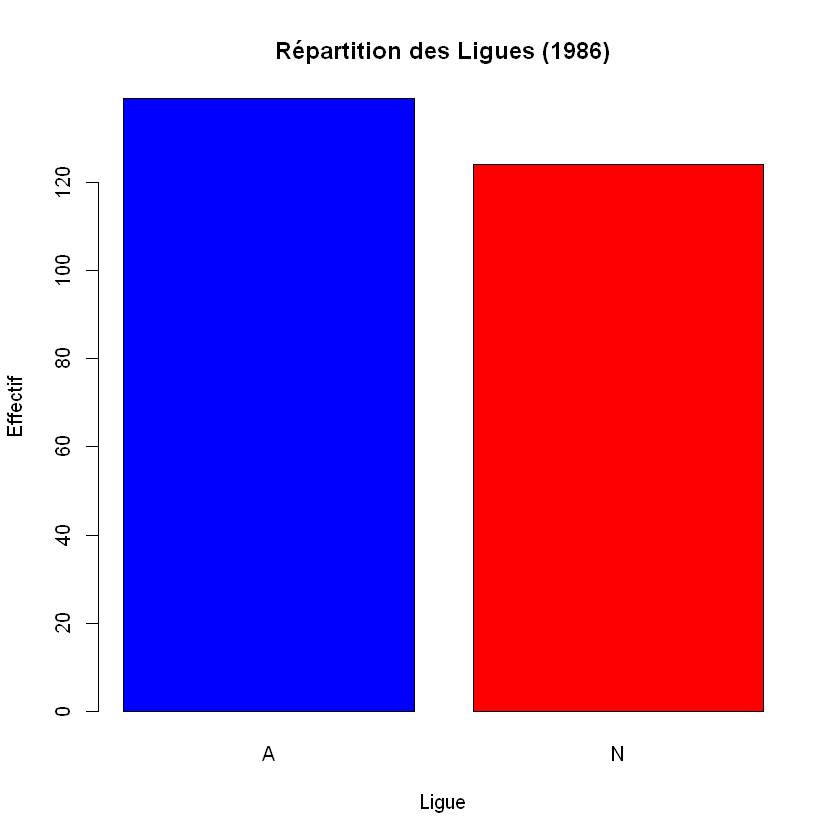

```r
# Année 1986
table_league <- table(Baseball$League_1986)
prop_table_league <- prop.table(table_league) * 100
print(table_league)
print(prop_table_league)
barplot(table_league, col = c("blue", "red"), main = "Répartition des Ligues (1986)",
        xlab = "Ligue", ylab = "Effectif")
```

```
  A   N
141 122

       A        N
53.61217 46.38783
```

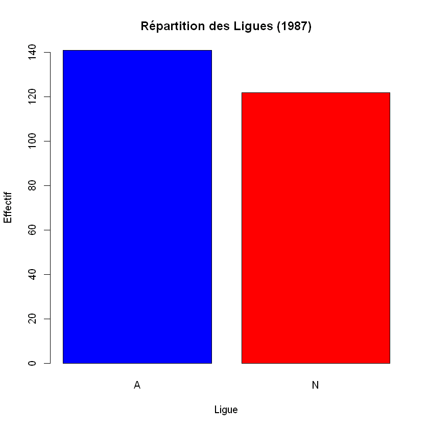

```r
# Année 1987
table_league <- table(Baseball$League_1987)
prop_table_league <- prop.table(table_league) * 100
print(table_league)
print(prop_table_league)
barplot(table_league, col = c("blue", "red"), main = "Répartition des Ligues (1987)",
        xlab = "Ligue", ylab = "Effectif")
```

### 1.3.4. Analyse des salaires en fonction de League_1986 et League_1987 avec comparaison

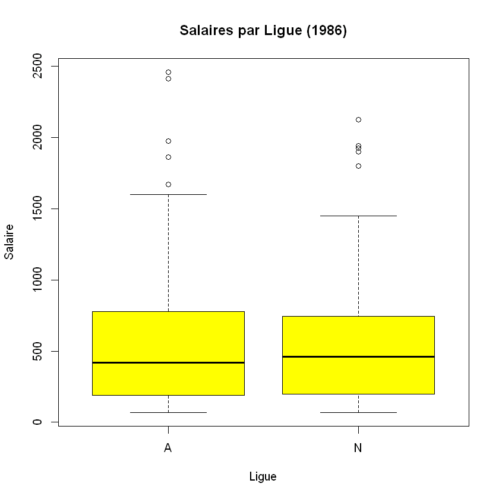

```r
boxplot(Salary_1987 ~ League_1986, data = Baseball, main = "Salaires par Ligue (1986)", xlab = "Ligue", ylab = "Salaire", col = "yellow")
```

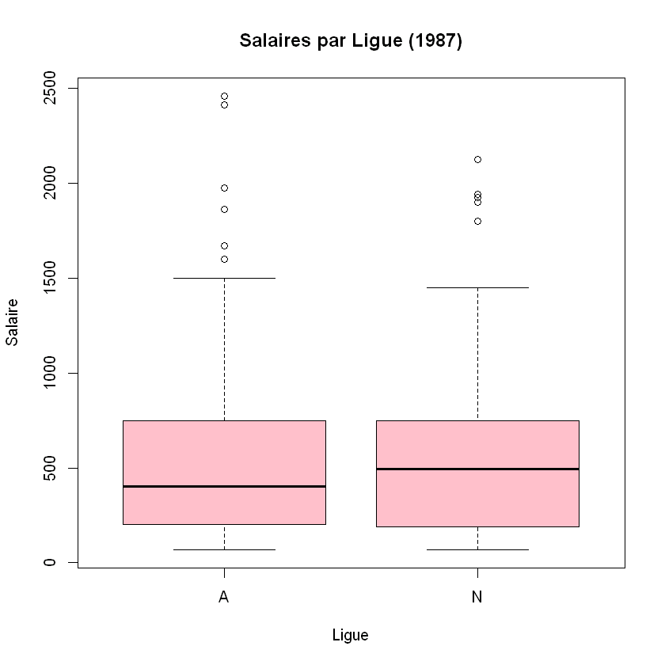

```r
boxplot(Salary_1987 ~ League_1987, data = Baseball, main = "Salaires par Ligue (1987)", xlab = "Ligue", ylab = "Salaire", col = "pink")
```

### 1.3.5. Analyse des performances en 1986

```r
# Statistiques descriptives
summary(Baseball$Bat_times_86)  # Apparitions au bâton
summary(Baseball$Hits_86)       # Coups sûrs
summary(Baseball$Home_runs_1986) # Home runs

# Moyenne et écart-type
mean(Baseball$Bat_times_86, na.rm = TRUE)
sd(Baseball$Bat_times_86, na.rm = TRUE)
```

```
   Min. 1st Qu.  Median    Mean 3rd Qu.    Max.
  127.0   285.5   416.0   408.3   527.0   687.0
```

```
   Min. 1st Qu.  Median    Mean 3rd Qu.    Max.
   32.0    73.0   108.0   109.2   142.0   238.0
```

```
   Min. 1st Qu.  Median    Mean 3rd Qu.    Max.
   0.00    5.00    9.00   11.83   18.00   40.00
```

408.285171102662

142.633058438138

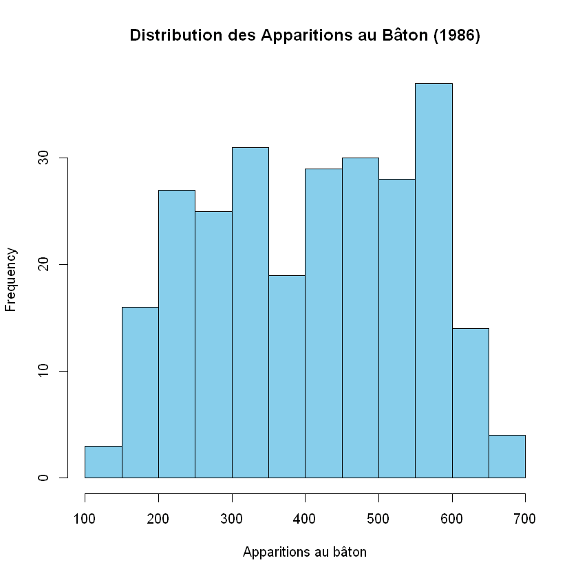

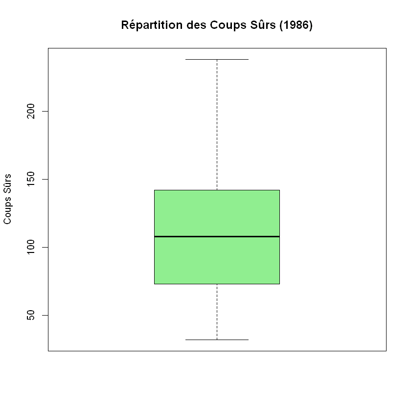

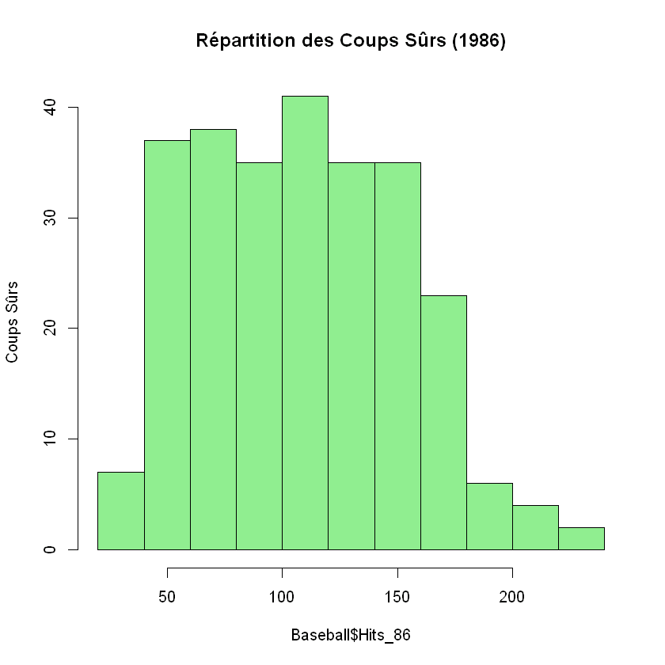

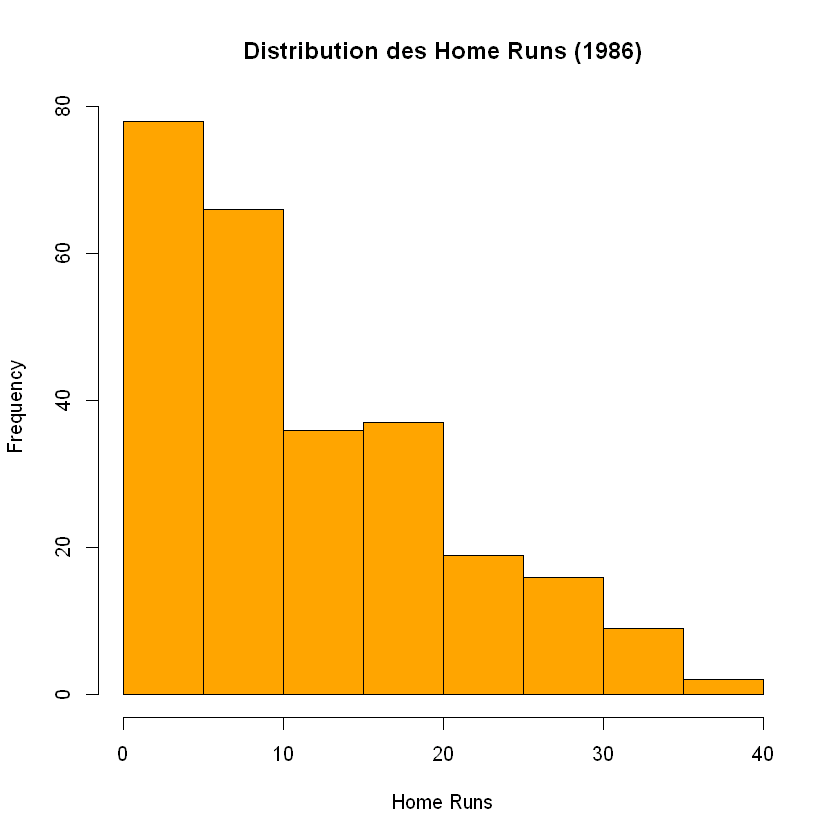

```r
# Histogramme des apparitions au bâton
hist(Baseball$Bat_times_86,
     main = "Distribution des Apparitions au Bâton (1986)",
     xlab = "Apparitions au bâton",
     col = "skyblue",
     breaks = 10)

# Boxplot des coups sûrs
boxplot(Baseball$Hits_86,
        main = "Répartition des Coups Sûrs (1986)",
        ylab = "Coups Sûrs",
        col = "lightgreen")
hist(Baseball$Hits_86,
        main = "Répartition des Coups Sûrs (1986)",
        ylab = "Coups Sûrs",
        col = "lightgreen")

# Histogramme des home runs
hist(Baseball$Home_runs_1986,
     main = "Distribution des Home Runs (1986)",
     xlab = "Home Runs",
     col = "orange",
     breaks = 10)
```

```r
# Joueurs avec le plus grand nombre de coups sûrs
top_hits <- Baseball[Baseball$Hits_86 == max(Baseball$Hits_86, na.rm = TRUE), ]
print(top_hits)

# Joueurs avec le plus grand nombre de home runs
top_home_runs <- Baseball[Baseball$Home_runs_1986 == max(Baseball$Home_runs_1986, na.rm = TRUE), ]
print(top_home_runs)
```

```
            Name Bat_times_86 Hits_86 Home_runs_1986 Runs_1986 Runs_batted_1986
83 Don Mattingly          677     238             31       117              113
   Walks_1986 Longevity Bat_times_career Hits_career Home_runs_career
83         53         5             2223         737               93
   Runs_career Runs_batted_career Walks_career League_1986 Division_1986
83         349                401          171           A             E
   Team_1986 Position_1986 Put_outs_1986 Assists_1986 Errors_1986 Salary_1987
83      N.Y.            1B          1377          100           6        1975
   League_1987 Team_1987
83           A      N.Y.
              Name Bat_times_86 Hits_86 Home_runs_1986 Runs_1986
137 Jesse Barfield          589     170             40       107
    Runs_batted_1986 Walks_1986 Longevity Bat_times_career Hits_career
137              108         69         6             2325         634
    Home_runs_career Runs_career Runs_batted_career Walks_career League_1986
137              128         371                376          238           A
    Division_1986 Team_1986 Position_1986 Put_outs_1986 Assists_1986
137             E      Tor.            RF           368           20
    Errors_1986 Salary_1987 League_1987 Team_1987
137           3      1237.5           A      Tor.
```

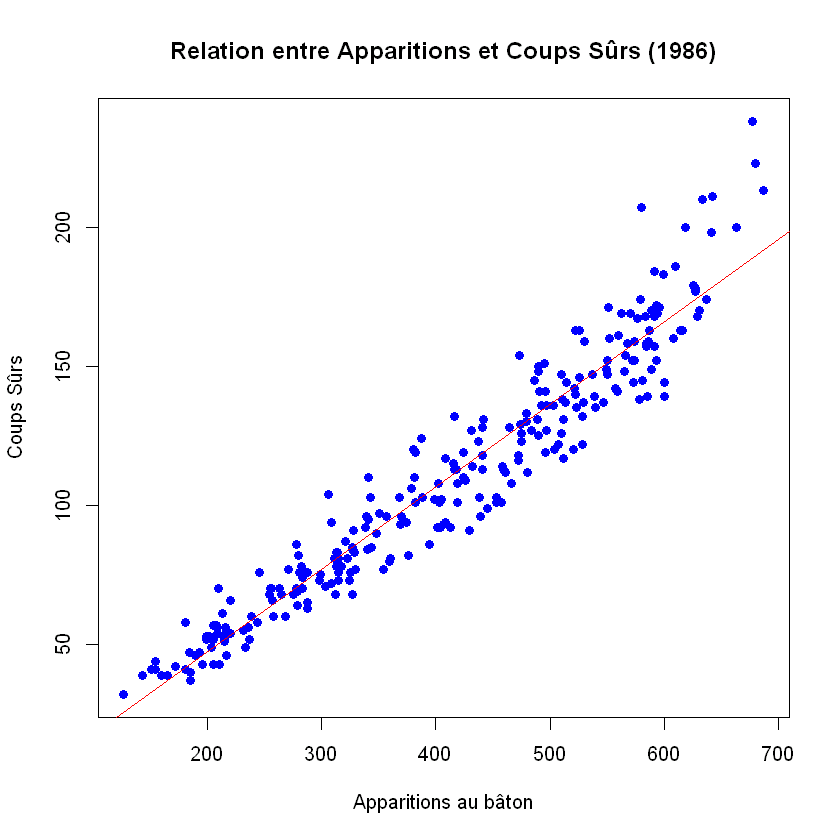

```r
# Graphique de dispersion
plot(Baseball$Bat_times_86, Baseball$Hits_86,
     main = "Relation entre Apparitions et Coups Sûrs (1986)",
     xlab = "Apparitions au bâton",
     ylab = "Coups Sûrs",
     col = "blue",
     pch = 16)

# Ajouter une ligne de tendance
abline(lm(Baseball$Hits_86 ~ Baseball$Bat_times_86, data = Baseball), col = "red")
```

```
   Min. 1st Qu.  Median    Mean 3rd Qu.    Max.
 0.2000  0.2452  0.2632  0.2638  0.2798  0.3569
```

```
   Min. 1st Qu.  Median    Mean 3rd Qu.    Max.
   22.0    66.0   103.0   107.8   143.0   230.0
```

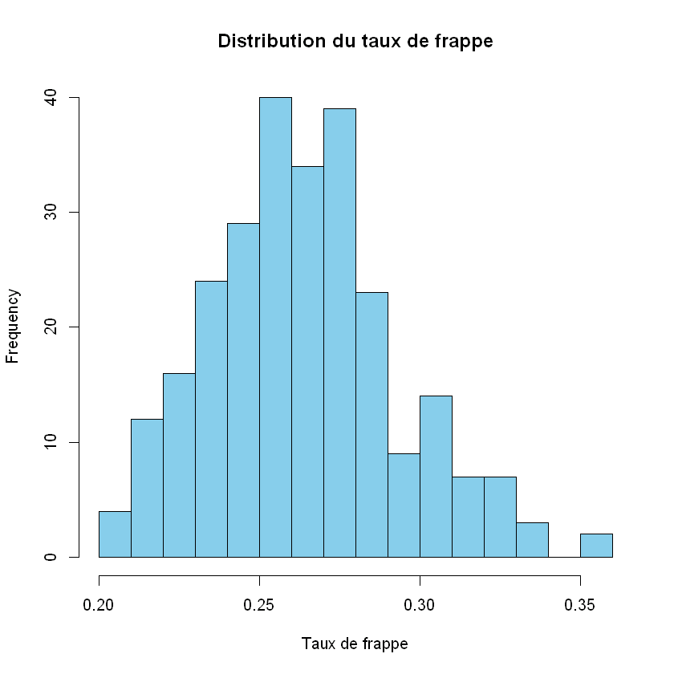

```r
# Ajouter des indicateurs
Baseball$Batting_Average <- Baseball$Hits_86 / Baseball$Bat_times_86 # Ce ratio mesure l’efficacité du joueur à frapper la balle.
Baseball$Total_Contribution <- Baseball$Runs_1986 + Baseball$Runs_batted_1986 # Cela mesure combien de points le joueur a contribué directement ou indirectement.


# Résumé des indicateurs
summary(Baseball$Batting_Average)
summary(Baseball$Total_Contribution)

# Visualisation
hist(Baseball$Batting_Average, main = "Distribution du taux de frappe", xlab = "Taux de frappe", col = "skyblue", breaks = 20)
```

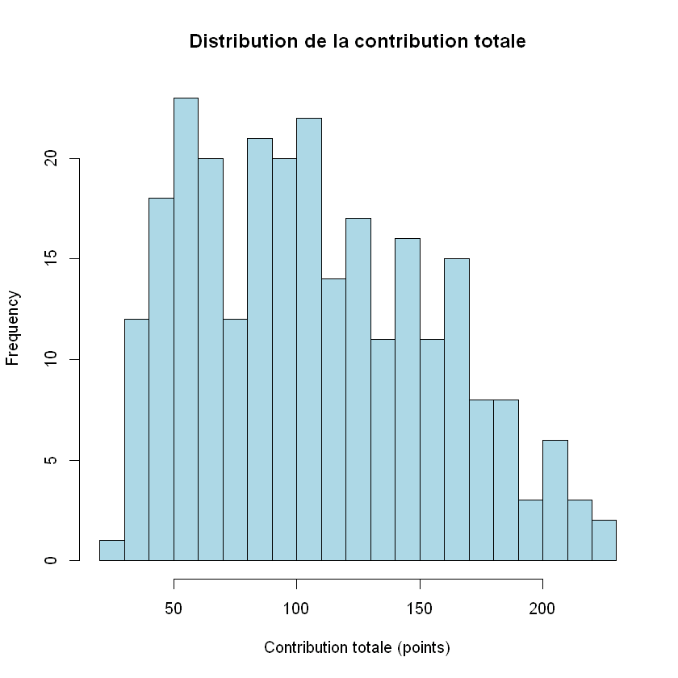

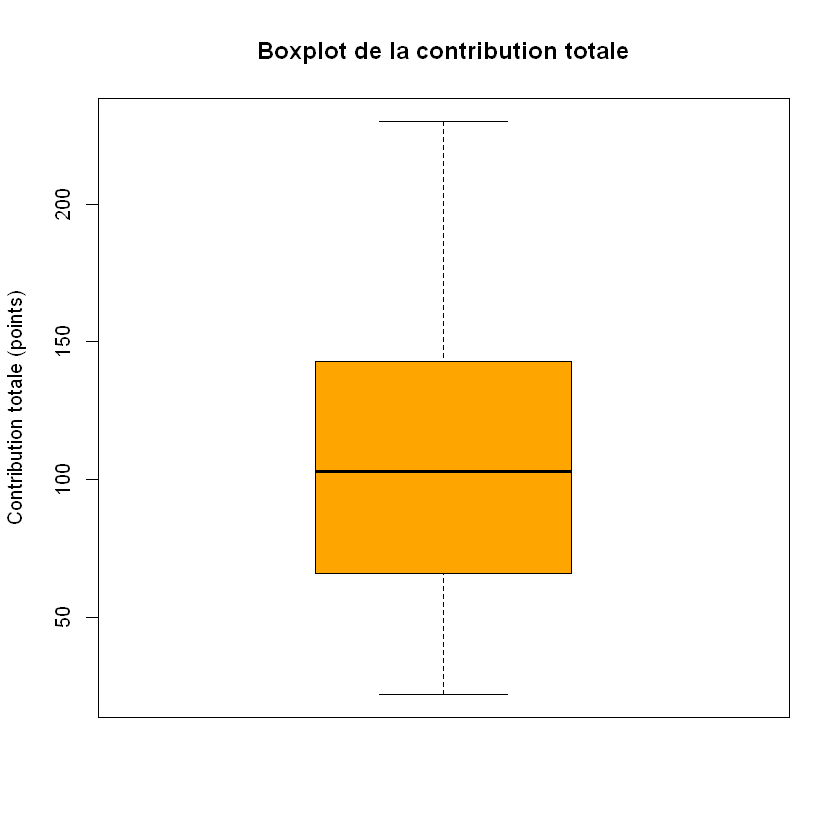

```r
hist(Baseball$Total_Contribution,
     main = "Distribution de la contribution totale",
     xlab = "Contribution totale (points)",
     col = "lightblue",
     breaks = 20)

boxplot(Baseball$Total_Contribution,
        main = "Boxplot de la contribution totale",
        ylab = "Contribution totale (points)",
        col = "orange")
```

```
   Min. 1st Qu.  Median    Mean 3rd Qu.    Max.
0.01408 0.07564 0.09896 0.10300 0.12730 0.25581
```

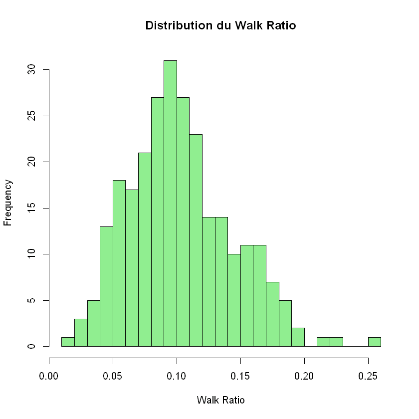

```r
# Vérification des valeurs valides pour éviter des divisions par zéro
Baseball$Walk_Ratio <- ifelse(Baseball$Bat_times_86 > 0 & !is.na(Baseball$Bat_times_86),
                              Baseball$Walks_1986 / Baseball$Bat_times_86,
                              NA)
#Ce ratio représente la proportion de fois où un joueur a obtenu une base sur balles par rapport à ses apparitions au bâton.
# Résumé statistique
summary(Baseball$Walk_Ratio)

# Visualisation
hist(Baseball$Walk_Ratio, main = "Distribution du Walk Ratio",
     xlab = "Walk Ratio", col = "lightgreen", breaks = 20)
```

```
   Min. 1st Qu.  Median    Mean 3rd Qu.    Max.    NA's
 0.8653  0.9682  0.9798  0.9752  0.9888  1.0000      11
```

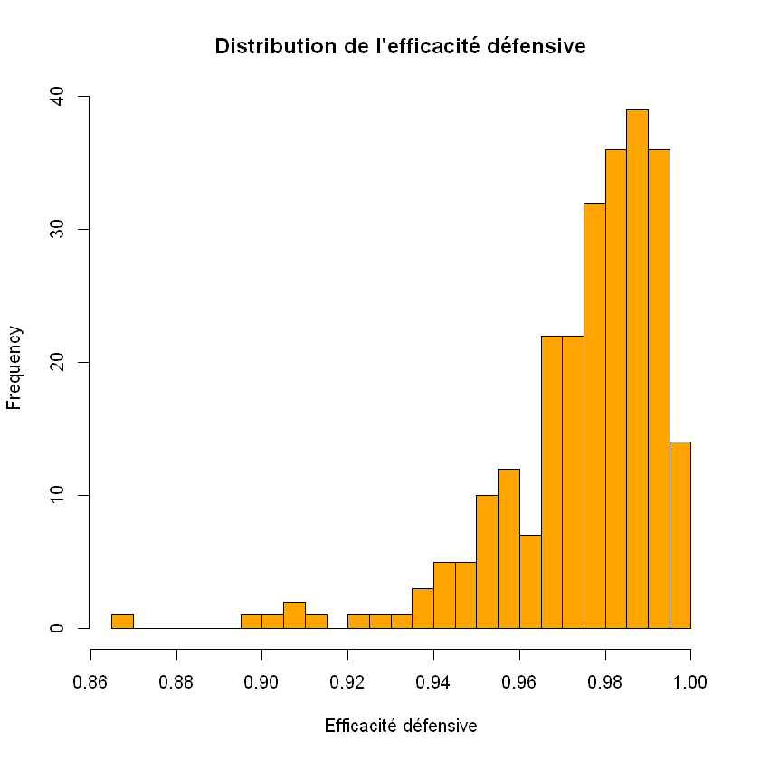

```r
# Calcul de l'efficacité défensive
Baseball$Defensive_Efficiency <- ifelse(
  (Baseball$Put_outs_1986 + Baseball$Assists_1986 + Baseball$Errors_1986) > 0,
  (Baseball$Put_outs_1986 + Baseball$Assists_1986) /
  (Baseball$Put_outs_1986 + Baseball$Assists_1986 + Baseball$Errors_1986),
  NA
)

# Résumé statistique
summary(Baseball$Defensive_Efficiency)

# Visualisation
hist(Baseball$Defensive_Efficiency, main = "Distribution de l'efficacité défensive",
     xlab = "Efficacité défensive", col = "orange", breaks = 20)
```

Pour améliorer la qualité du modèle (R²) vaut mieux qu'on ajoute d'autres variables

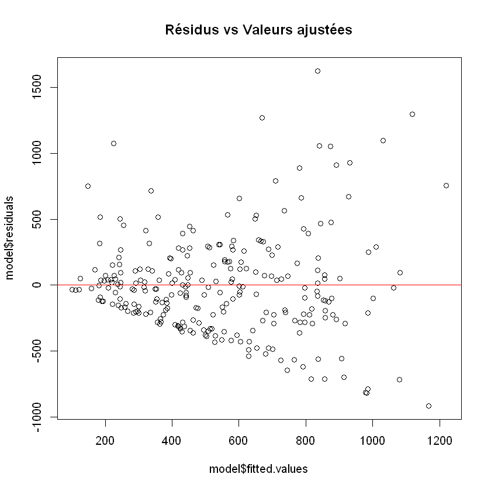

```r
plot(model$residuals ~ model$fitted.values, main = "Résidus vs Valeurs ajustées")
abline(h = 0, col = "red")
```

# 2. ACP et questions soulevées

## 2.1. Prétaitement des données

```r
# Variable numérique uniquement
Baseball_num = na.omit(Baseball[,c(-1,-15,-16,-17,-18,-23,-24)])
head(Baseball_num)

data_norm = scale(Baseball_num)
ACP_data = dudi.pca(df = data_norm, scannf = FALSE, nf = 3)

summary(ACP_data)
```

A data.frame: 6 × 17

|  | Bat_times_86 <int> | Hits_86 <int> | Home_runs_1986 <int> | Runs_1986 <int> | Runs_batted_1986 <int> | Walks_1986 <int> | Longevity <int> | Bat_times_career <int> | Hits_career <int> | Home_runs_career <int> | Runs_career <int> | Runs_batted_career <int> | Walks_career <int> | Put_outs_1986 <int> | Assists_1986 <int> | Errors_1986 <int> | Salary_1987 <dbl> |
| --- | --- | --- | --- | --- | --- | --- | --- | --- | --- | --- | --- | --- | --- | --- | --- | --- | --- |
| 2 | 315 | 81 | 7 | 24 | 38 | 39 | 14 | 3449 | 835 | 69 | 321 | 414 | 375 | 632 | 43 | 10 | 475.0 |
| 3 | 479 | 130 | 18 | 66 | 72 | 76 | 3 | 1624 | 457 | 63 | 224 | 266 | 263 | 880 | 82 | 14 | 480.0 |
| 4 | 496 | 141 | 20 | 65 | 78 | 37 | 11 | 5628 | 1575 | 225 | 828 | 838 | 354 | 200 | 11 | 3 | 500.0 |
| 5 | 321 | 87 | 10 | 39 | 42 | 30 | 2 | 396 | 101 | 12 | 48 | 46 | 33 | 805 | 40 | 4 | 91.5 |
| 6 | 594 | 169 | 4 | 74 | 51 | 35 | 11 | 4408 | 1133 | 19 | 501 | 336 | 194 | 282 | 421 | 25 | 750.0 |
| 7 | 185 | 37 | 1 | 23 | 8 | 21 | 2 | 214 | 42 | 1 | 30 | 9 | 24 | 76 | 127 | 7 | 70.0 |

```
Class: pca dudi
Call: dudi.pca(df = data_norm, scannf = FALSE, nf = 3)

Total inertia: 17

Eigenvalues:
    Ax1     Ax2     Ax3     Ax4     Ax5
 7.7632  4.1345  1.7264  0.8989  0.7066

Projected inertia (%):
    Ax1     Ax2     Ax3     Ax4     Ax5
 45.666  24.320  10.155   5.287   4.156

Cumulative projected inertia (%):
    Ax1   Ax1:2   Ax1:3   Ax1:4   Ax1:5
  45.67   69.99   80.14   85.43   89.59

(Only 5 dimensions (out of 17) are shown)
```

## 2.2. Visualisation des corrélations

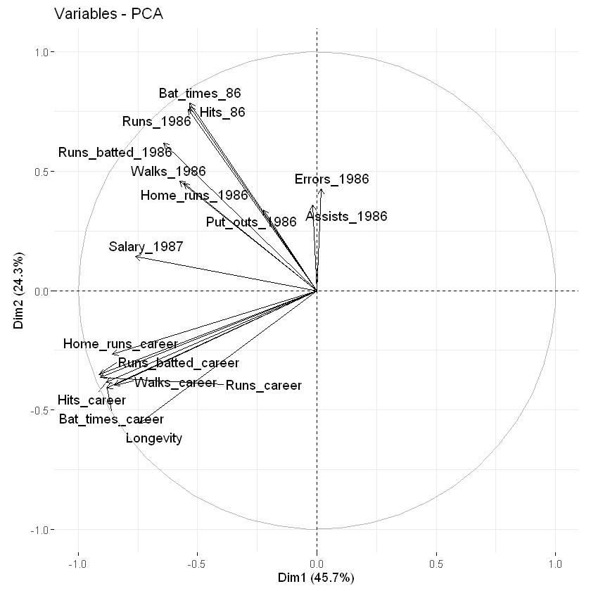

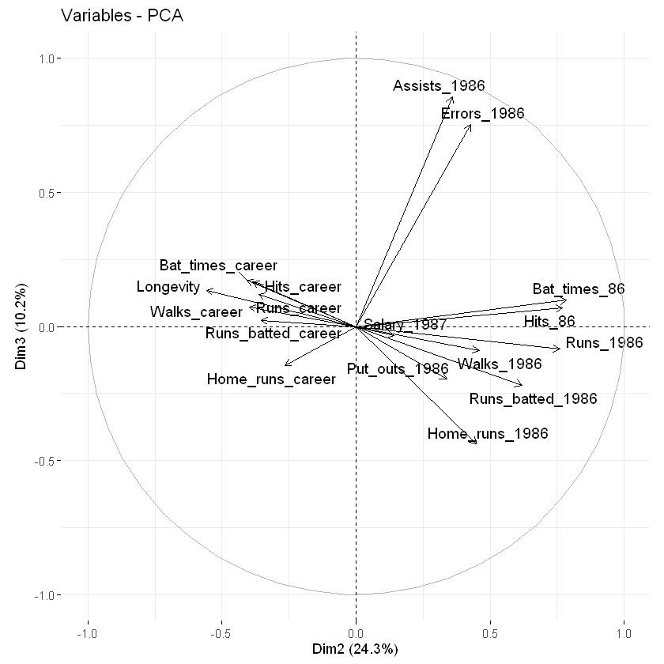

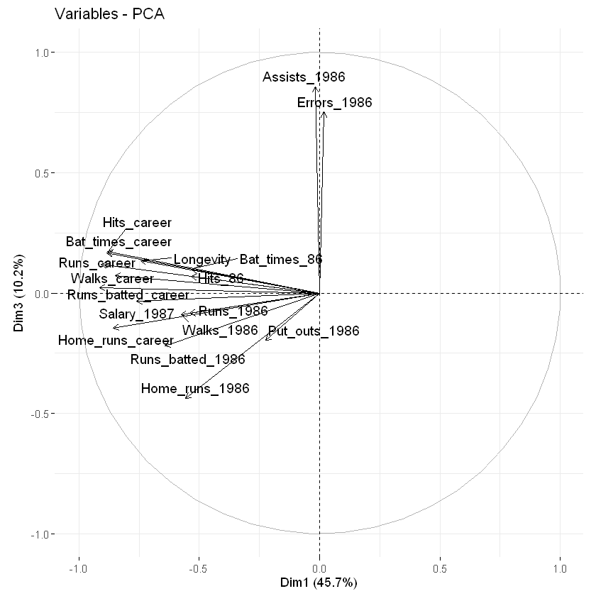

```r
# Affiche le cercle des corrélations
fviz_pca_var(ACP_data, axes = c(1,2), repel=TRUE)
fviz_pca_var(ACP_data, axes = c(2,3), repel=TRUE)
fviz_pca_var(ACP_data, axes = c(1,3), repel=TRUE)
```

### 2.4.1. Les performances de 1986 sont-elles particulières par rapport aux performances sur l'ensemble de la carrière ?

```r
var_86 = Baseball[,c(2,3,4,5,6,7)]
head(var_86)
var_career = Baseball[,c(9,10,11,12,13,14)]
var_career = var_career/Baseball$Longevity
var_career[] <- lapply(var_career, as.integer)
head(var_career)
```

A data.frame: 6 × 6

|  | Bat_times_86 <int> | Hits_86 <int> | Home_runs_1986 <int> | Runs_1986 <int> | Runs_batted_1986 <int> | Walks_1986 <int> |
| --- | --- | --- | --- | --- | --- | --- |
| 2 | 315 | 81 | 7 | 24 | 38 | 39 |
| 3 | 479 | 130 | 18 | 66 | 72 | 76 |
| 4 | 496 | 141 | 20 | 65 | 78 | 37 |
| 5 | 321 | 87 | 10 | 39 | 42 | 30 |
| 6 | 594 | 169 | 4 | 74 | 51 | 35 |
| 7 | 185 | 37 | 1 | 23 | 8 | 21 |

A data.frame: 6 × 6

|  | Bat_times_career <int> | Hits_career <int> | Home_runs_career <int> | Runs_career <int> | Runs_batted_career <int> | Walks_career <int> |
| --- | --- | --- | --- | --- | --- | --- |
| 2 | 246 | 59 | 4 | 22 | 29 | 26 |
| 3 | 541 | 152 | 21 | 74 | 88 | 87 |
| 4 | 511 | 143 | 20 | 75 | 76 | 32 |
| 5 | 198 | 50 | 6 | 24 | 23 | 16 |
| 6 | 400 | 103 | 1 | 45 | 30 | 17 |
| 7 | 107 | 21 | 0 | 15 | 4 | 12 |

```r
cor(var_86)
cor(var_career)
```

A matrix: 6 × 6 of type dbl

|  | Bat_times_86 | Hits_86 | Home_runs_1986 | Runs_1986 | Runs_batted_1986 | Walks_1986 |
| --- | --- | --- | --- | --- | --- | --- |
| Bat_times_86 | 1.0000000 | 0.9621306 | 0.5463554 | 0.8941126 | 0.7851417 | 0.6077128 |
| Hits_86 | 0.9621306 | 1.0000000 | 0.5224638 | 0.9057084 | 0.7782902 | 0.5711552 |
| Home_runs_1986 | 0.5463554 | 0.5224638 | 1.0000000 | 0.6275694 | 0.8515637 | 0.4406703 |
| Runs_1986 | 0.8941126 | 0.9057084 | 0.6275694 | 1.0000000 | 0.7705897 | 0.6877491 |
| Runs_batted_1986 | 0.7851417 | 0.7782902 | 0.8515637 | 0.7705897 | 1.0000000 | 0.5618071 |
| Walks_1986 | 0.6077128 | 0.5711552 | 0.4406703 | 0.6877491 | 0.5618071 | 1.0000000 |

A matrix: 6 × 6 of type dbl

|  | Bat_times_career | Hits_career | Home_runs_career | Runs_career | Runs_batted_career | Walks_career |
| --- | --- | --- | --- | --- | --- | --- |
| Bat_times_career | 1.0000000 | 0.9817572 | 0.5525338 | 0.9403531 | 0.8330020 | 0.6981114 |
| Hits_career | 0.9817572 | 1.0000000 | 0.5291286 | 0.9412507 | 0.8341644 | 0.6743479 |
| Home_runs_career | 0.5525338 | 0.5291286 | 1.0000000 | 0.6084114 | 0.8626287 | 0.5557659 |
| Runs_career | 0.9403531 | 0.9412507 | 0.6084114 | 1.0000000 | 0.8127461 | 0.7774633 |
| Runs_batted_career | 0.8330020 | 0.8341644 | 0.8626287 | 0.8127461 | 1.0000000 | 0.6783033 |
| Walks_career | 0.6981114 | 0.6743479 | 0.5557659 | 0.7774633 | 0.6783033 | 1.0000000 |

```r
bat_times = Baseball[,c(2,9)]
hits = Baseball[,c(3,10)]
home_runs = Baseball[,c(4,11)]
runs = Baseball[,c(5,12)]
runs_batted = Baseball[,c(6,13)]
walks = Baseball[,c(7,14)]

cor(bat_times)
cor(hits)
cor(home_runs)
cor(runs)
cor(runs_batted)
cor(walks)
```

A matrix: 2 × 2 of type dbl

|  | Bat_times_86 | Bat_times_career |
| --- | --- | --- |
| Bat_times_86 | 1.0000000 | 0.1898581 |
| Bat_times_career | 0.1898581 | 1.0000000 |

A matrix: 2 × 2 of type dbl

|  | Hits_86 | Hits_career |
| --- | --- | --- |
| Hits_86 | 1.0000000 | 0.2221684 |
| Hits_career | 0.2221684 | 1.0000000 |

A matrix: 2 × 2 of type dbl

|  | Home_runs_1986 | Home_runs_career |
| --- | --- | --- |
| Home_runs_1986 | 1.0000000 | 0.5108369 |
| Home_runs_career | 0.5108369 | 1.0000000 |

A matrix: 2 × 2 of type dbl

|  | Runs_1986 | Runs_career |
| --- | --- | --- |
| Runs_1986 | 1.0000000 | 0.2323638 |
| Runs_career | 0.2323638 | 1.0000000 |

A matrix: 2 × 2 of type dbl

|  | Runs_batted_1986 | Runs_batted_career |
| --- | --- | --- |
| Runs_batted_1986 | 1.0000000 | 0.3960386 |
| Runs_batted_career | 0.3960386 | 1.0000000 |

A matrix: 2 × 2 of type dbl

|  | Walks_1986 | Walks_career |
| --- | --- | --- |
| Walks_1986 | 1.0000000 | 0.4359526 |
| Walks_career | 0.4359526 | 1.0000000 |

```
                 Salary_1987   Hits_86 Home_runs_1986 Runs_batted_1986
Salary_1987        1.0000000 0.5128498      0.3923546        0.5162758
Hits_86            0.5128498 1.0000000      0.5224638        0.7782902
Home_runs_1986     0.3923546 0.5224638      1.0000000        0.8515637
Runs_batted_1986   0.5162758 0.7782902      0.8515637        1.0000000
```

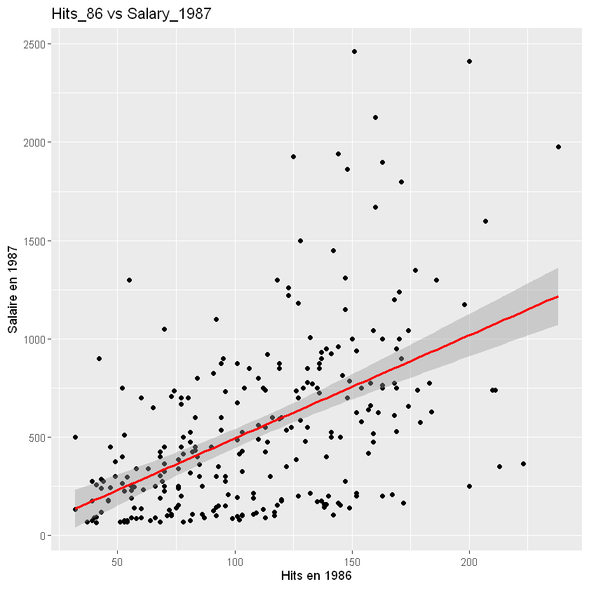

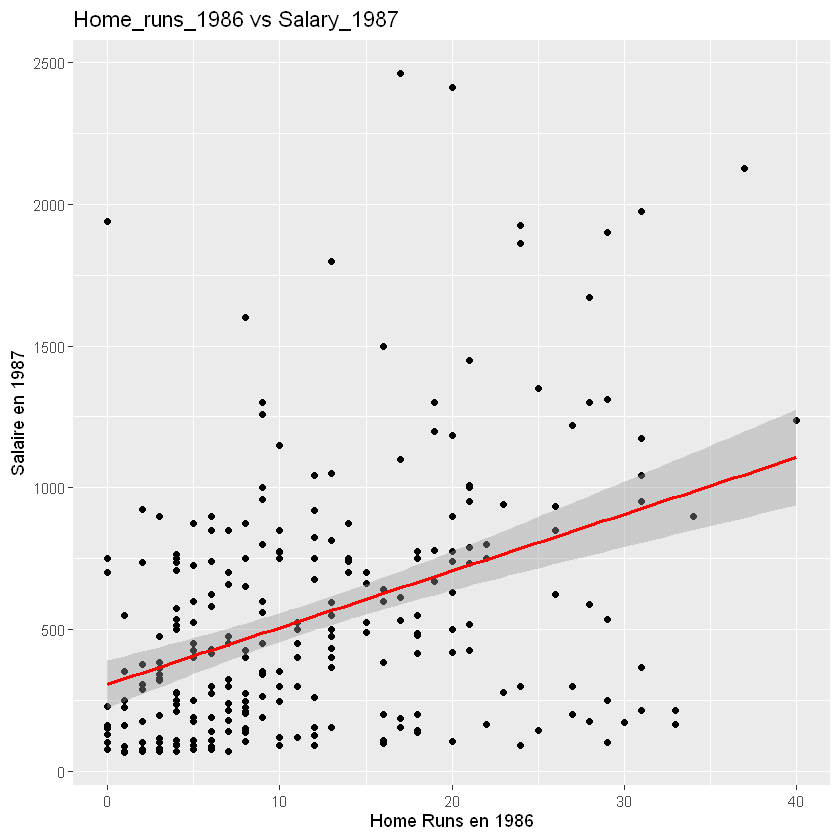

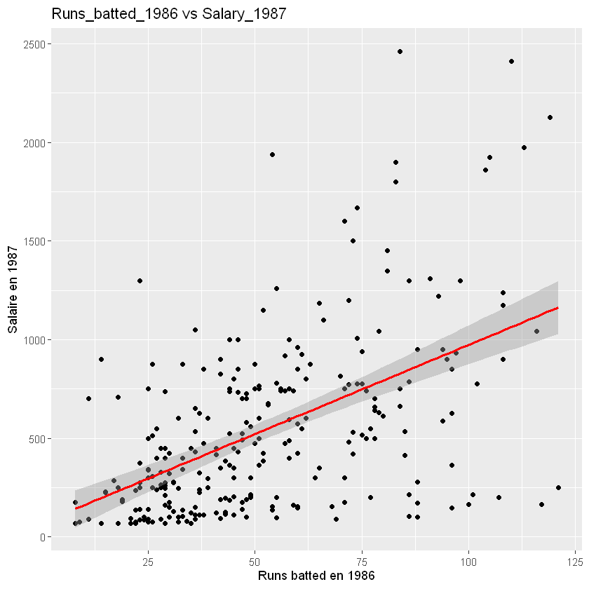

```r
subset_data <- Baseball[c("Salary_1987","Hits_86", "Home_runs_1986", "Runs_batted_1986")]
cor_subset <- cor(subset_data, use = "complete.obs")
print(cor_subset)

# Nuage de points pour Hits_86 vs Salary_1987
ggplot(subset_data, aes(x = Hits_86, y = Salary_1987)) +
  geom_point(color = "black") +
  geom_smooth(method = "lm", col = "red") +
  labs(title = "Hits_86 vs Salary_1987", x = "Hits en 1986", y = "Salaire en 1987")

# Nuage de points pour Home_runs_1986 vs Salary_1987
ggplot(subset_data, aes(x = Home_runs_1986, y = Salary_1987)) +
  geom_point(color = "black") +
  geom_smooth(method = "lm", col = "red") +
  labs(title = "Home_runs_1986 vs Salary_1987", x = "Home Runs en 1986", y = "Salaire en 1987")

# Nuage de points pour Runs_batted_1986 vs Salary_1987
ggplot(subset_data, aes(x = Runs_batted_1986, y = Salary_1987)) +
  geom_point(color = "black") +
  geom_smooth(method = "lm", col = "red") +
  labs(title = "Runs_batted_1986 vs Salary_1987", x = "Runs batted en 1986", y = "Salaire en 1987")
```

Graphique (Home_runs_1986 vs Salary_1987) :

La relation entre les "Home Runs" réalisés en 1986 et le salaire en 1987 semble être positive mais faible. La ligne de régression montre une légère tendance croissante. Cependant, il y a beaucoup de dispersion autour de la ligne, ce qui signifie que le nombre de home runs n'explique pas complètement le salaire. Tableau de corrélation :

La corrélation entre Home_runs_1986 et Salary_1987 est de 0.39 (positive mais relativement faible). En revanche, Hits_86 et Runs_batted_1986 montrent des corrélations plus fortes avec Salary_1987 (0.51 et 0.52 respectivement), suggérant qu'ils pourraient être des facteurs plus significatifs.

Pourquoi autant de points éloignés de la ligne de régression ? Cela peut s'expliquer par :

Autres facteurs : Le salaire dépend probablement d'autres variables importantes (popularité, ancienneté, position, etc.). Variabilité naturelle : Certains joueurs peuvent avoir des salaires élevés pour des raisons indépendantes de leurs statistiques sportives. Relation faible : La corrélation de 0.39 montre qu'il y a une certaine relation, mais pas assez forte pour expliquer la majorité des salaires.

```r
model <- lm(Salary_1987 ~ Hits_86 + Home_runs_1986 + Runs_batted_1986, data = subset_data)
summary(model)
```

```
Call:
lm(formula = Salary_1987 ~ Hits_86 + Home_runs_1986 + Runs_batted_1986,
    data = subset_data)

Residuals:
    Min      1Q  Median      3Q     Max
-916.31 -222.30  -30.71  161.58 1625.15

Coefficients:
                 Estimate Std. Error t value Pr(>|t|)
(Intercept)      -45.2175    62.8683  -0.719  0.47264
Hits_86            2.7548     0.9374   2.939  0.00359 **
Home_runs_1986    -1.7622     5.5964  -0.315  0.75310
Runs_batted_1986   5.8816     2.6086   2.255  0.02499 *
---
Signif. codes:  0 '***' 0.001 '**' 0.01 '*' 0.05 '.' 0.1 ' ' 1

Residual standard error: 379.2 on 259 degrees of freedom
Multiple R-squared:  0.2981,	Adjusted R-squared:   0.29
F-statistic: 36.66 on 3 and 259 DF,  p-value: < 2.2e-16
```

```
	Shapiro-Wilk normality test

data:  model$residuals
W = 0.94723, p-value = 3.882e-08
```

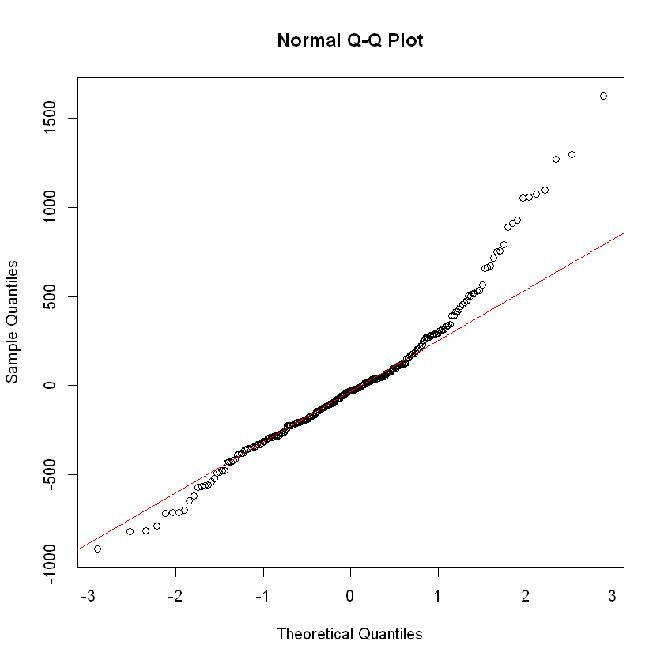

```r
qqnorm(model$residuals)
qqline(model$residuals, col = "red")
shapiro.test(model$residuals)
```

### 2.4.2. Est-ce que la longévité de la carrière et le salaire perçu est lié ?

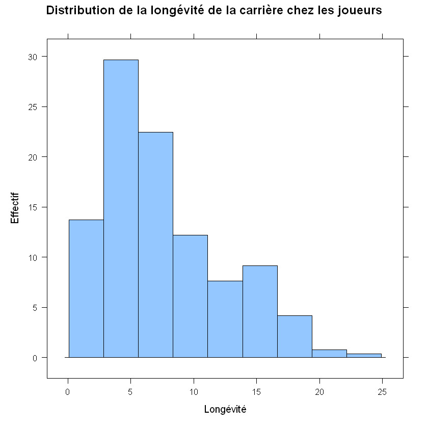

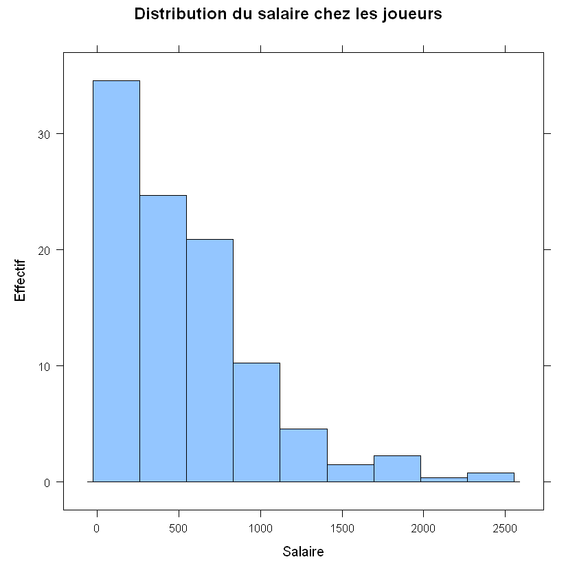

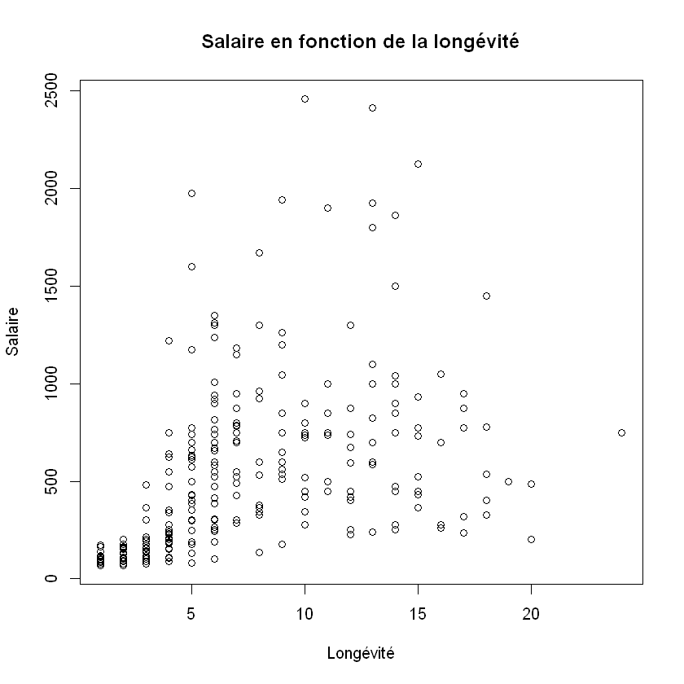

**null device:** 1

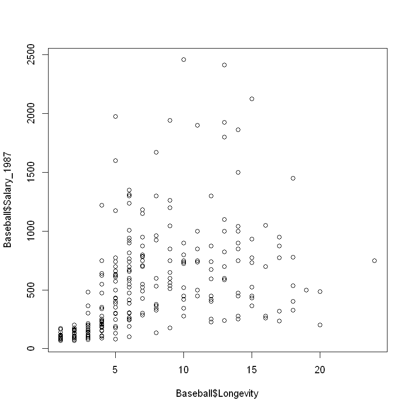

```r
histogram(~ Baseball$Longevity, xlab="Longévité", ylab="Effectif", main="Distribution de la longévité de la carrière chez les joueurs")
histogram(~ Baseball$Salary_1987, xlab="Salaire", ylab="Effectif", main="Distribution du salaire chez les joueurs")
par(bg = "white")
plot(Baseball$Longevity, Baseball$Salary_1987, xlab="Longévité", ylab="Salaire", main="Salaire en fonction de la longévité")


#png("salaire_longetivite.png", bg = "white")
plot(Baseball$Longevity, Baseball$Salary_1987)
dev.off()
```

```r
table(Baseball$Longevity)

longevity_modif <- ifelse(Baseball$Longevity %in% c(16, 17), "16-17", as.character(Baseball$Longevity))
longevity_modif <- ifelse(longevity_modif %in% c(18, 19), "18-19", as.character(longevity_modif))
longevity_modif <- ifelse(longevity_modif %in% c(20, 24), "20+", as.character(longevity_modif))
longevity_modif <- as.factor(longevity_modif)
print(longevity_modif)
```

```
 1  2  3  4  5  6  7  8  9 10 11 12 13 14 15 16 17 18 19 20 24
16 20 24 28 26 29 19 11 12 12  8 10 10 12  8  4  5  5  1  2  1
```

```
  [1] 14    3     11    2     11    2     3     2     13    10    9     4
 [13] 6     13    15    5     8     1     1     6     18-19 6     7     10
 [25] 5     14    3     5     7     14    2     2     4     6     3     5
 [37] 6     16-17 2     9     12    6     4     12    6     1     16-17 4
 [49] 4     16-17 3     4     16-17 14    18-19 15    9     4     6     4
 [61] 15    5     11    9     14    2     16-17 4     5     4     1     3
 [73] 12    14    3     7     10    8     14    5     1     14    5     13
 [85] 3     6     4     16-17 9     8     15    20+   5     5     11    5
 [97] 8     5     7     7     5     18-19 4     9     3     6     15    2
[109] 2     4     12    16-17 6     14    5     11    15    2     1     10
[121] 10    5     13    3     6     3     13    14    3     4     6     4
[133] 13    3     11    5     1     8     14    13    6     10    4     2
[145] 9     10    7     3     1     7     2     12    15    6     7     10
[157] 13    3     10    1     5     7     2     2     13    6     9     1
[169] 3     6     3     3     15    7     3     3     4     7     4     5
[181] 2     2     9     7     4     14    1     9     20+   5     6     5
[193] 12    5     12    16-17 3     18-19 9     8     20+   5     11    6
[205] 12    10    9     1     7     4     6     6     4     3     1     12
[217] 1     10    13    6     3     4     2     2     6     18-19 4     2
[229] 4     6     8     8     6     4     8     4     5     7     8     4
[241] 6     7     6     16-17 7     3     5     10    18-19 4     7     2
[253] 6     7     7     5     1     1     5     12    6     8     11
Levels: 1 10 11 12 13 14 15 16-17 18-19 2 20+ 3 4 5 6 7 8 9
```

```r
anova1 <- oneway.test(Baseball$Salary_1987 ~ longevity_modif, var.equal = FALSE)
print(anova1)
```

```
	One-way analysis of means (not assuming equal variances)

data:  Baseball$Salary_1987 and longevity_modif
F = 19.613, num df = 17.000, denom df = 55.493, p-value < 2.2e-16
```

# Bonus

```r
# Obtenir les effectifs par groupe

table(Baseball$Division_1986)
table(Baseball$Team_1986)
table(Baseball$Position_1986)
table(Baseball$League_1986)
table(Baseball$Team_1987)
table(Baseball$League_1987)
```

```
  E   W
129 134
```

```
 Atl.  Bal.  Bos.  Cal.  Chi.  Cin.  Cle.  Det.  Hou.  K.C.  L.A.  Mil.  Min.
    8    10     8    10    22    10    11    11    10     9    10    10    11
 Mon.  N.Y.  Oak.  Phi.  Pit.  S.D.  S.F.  Sea. St.L.  Tex.  Tor.
    9    20     8    10     9    12    13    11    11    11     9
```

```
1B 1O 23 2B 2S 32 3B 3O 3S  C CD CF DH DO LF O1 OD OF OS RF S3 SS UT
24  1  1 26  1  1 30  1  3 30  1 23 11  2 20  4  1 22  2 22  1 26 10
```

```
  A   N
139 124
```

```
 Atl.  Bal.  Bos.  Cal.  Chi.  Cin.  Cle.  Det.  Hou.  K.C.  L.A.  Mil.  Min.
    9    11     9     8    20     9    12    12    11     9     9    10    12
 Mon.  N.Y.  Oak.  Phi.  Pit.  S.D.  S.F.  Sea. St.L.  Tex.  Tor.
    8    21     9    11    13     9    14    10     9    10     8
```

```
  A   N
141 122
```

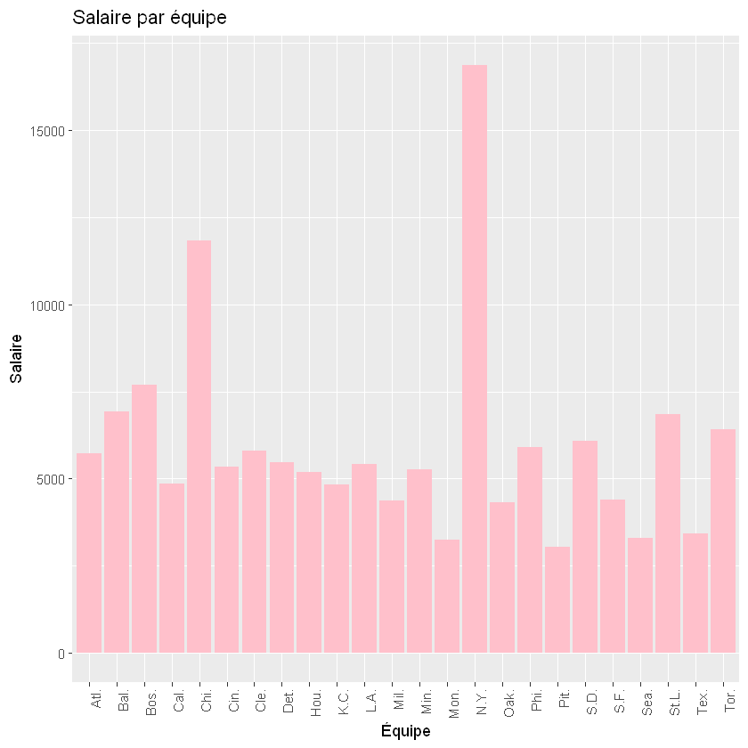

```r
# Analyser graphiquement les salaires en fonctions des équipes : Histogramme

ggplot(Baseball, aes(x = Team_1986, y = Salary_1987)) +
  geom_bar(stat = "identity",fill = "pink") +
  theme(axis.text.x = element_text(angle = 90, hjust = 1)) +
  labs(title = "Salaire par équipe", x = "Équipe", y = "Salaire")
```

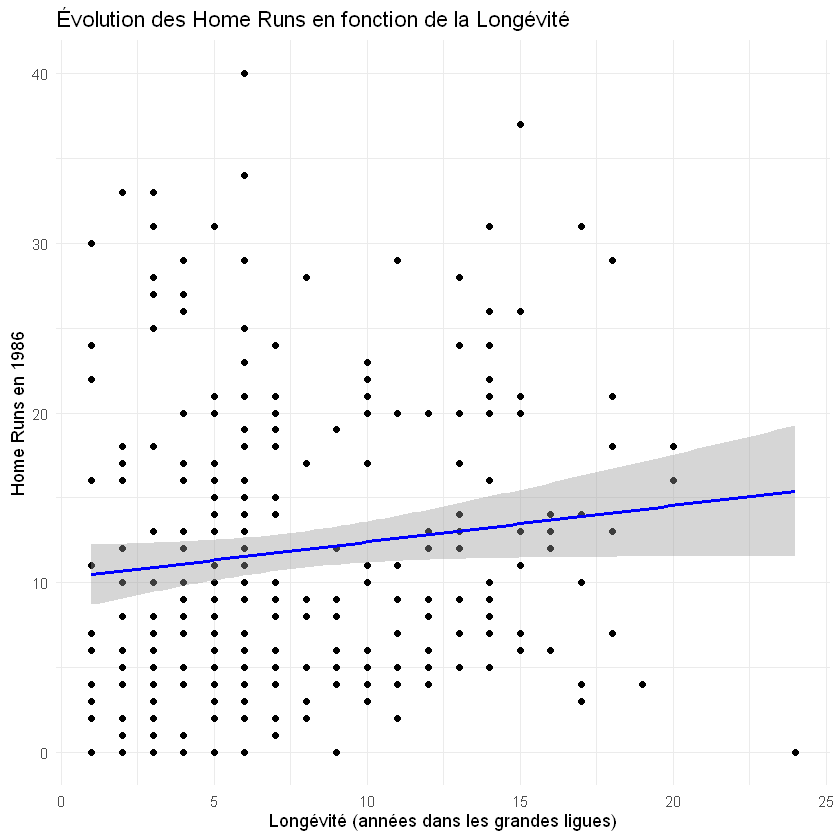

```r
# Analyser graphiquement les home run en fonction de la longevité : Courbe regréssion linéaire

ggplot(Baseball, aes(x = Longevity, y = Home_runs_1986)) +
  geom_point() +
  geom_smooth(method = "lm", color = "blue") +
  labs(title = "Évolution des Home Runs en fonction de la Longévité",
       x = "Longévité (années dans les grandes ligues)",
       y = "Home Runs en 1986") +
  theme_minimal()
```

```
                 Salary_1987   Hits_86 Home_runs_1986 Runs_batted_1986
Salary_1987        1.0000000 0.5128498      0.3923546        0.5162758
Hits_86            0.5128498 1.0000000      0.5224638        0.7782902
Home_runs_1986     0.3923546 0.5224638      1.0000000        0.8515637
Runs_batted_1986   0.5162758 0.7782902      0.8515637        1.0000000
```

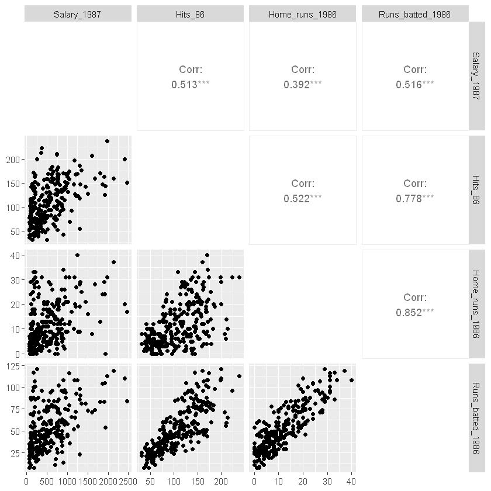

```r
# Analyser les corrélations entre performances et salaire

performances <- Baseball[, c("Salary_1987", "Hits_86", "Home_runs_1986", "Runs_batted_1986")]
ggpairs(performances,diag = list(continuous = "blankDiag"))
cor_matrix <- cor(performances, use = "complete.obs")
print(cor_matrix)
```